# Basic Markdown in Jupyter

# 1st Level header

## 2nd Level header

### 3rd Level header

### 4th Level header

*italic text*

**bold text**

> quote block
1. First item
2. Second item
3. Third item
- First item
- Second item
- Third item

`code`

blue color text

# Basic Python

## Variable Declaration and Basic Operation

There are *several* type of variables in Python, each with **their characteristic features**.

```python
a = 1 #integer any positive or negative number without decimal part
b = 'a' #string any ASCII or UNICODE symbol
c = 0.5 #float any positive or negative number with decimal part
d = False #boolean composed by True or False
e = None #None special type indicating the concept of nothingness e.g missing data
f = (1,1) #tuple store multiple items in a single variable in a ordered and unchangeable way
g = ['a',1] #list store multiple items in a single variable in a ordered and changeable way
h = {'a',1} #set store multiple items in a single variable in a unordered and unchangeable way
i = {'a':1} #dictionary store multiple items organized in keys pointing to values pairs
#they are changeable and do not allow duplicates
```

### Integer operations

```python
#variable declaration
a = 3
b = 2
```

```python
a + b #sum
```

```
5
```

```python
a * b #multiplication
```

```
6
```

```python
a - b #substraction
```

```
1
```

```python
a / b #division
```

```
1.5
```

```python
a % b #modulus
```

```
1
```

```python
a ** b #exponentiation
```

```
9
```

```python
a // b #floor division
```

```
1
```

### String operations

```python
#variable declaration
a = 'a'
b = 'b'
```

```python
a + b #concatenation
```

```
'ab'
```

```python
a = 'a'
```

```python
b = 2
```

it is **not** possible to concatenate string with other type of variables

```python
a + b
```

```
---------------------------------------------------------------------------
TypeError                                 Traceback (most recent call last)
/tmp/ipykernel_45815/1216668022.py in <module>
----> 1 a + b

TypeError: can only concatenate str (not "int") to str
```

it **is** possible to *convert* some type of variables in other types of variables

```python
a + str(b)
```

```
'a2'
```

```python
int(a) + b
```

```
---------------------------------------------------------------------------
ValueError                                Traceback (most recent call last)
/tmp/ipykernel_45815/3198875159.py in <module>
----> 1 int(a) + b

ValueError: invalid literal for int() with base 10: 'a'
```

## String

```python
my_string = 'hello world'
```

### String methods

```python
my_string.capitalize() #capitalization
```

```
'Hello world'
```

```python
my_string.replace(' world','!') #replacement
```

```
'hello!'
```

```python
my_string.title() #first letter of every word capitalized
```

```
'Hello World'
```

```python
my_string.upper() #all letter capitalized
```

```
'HELLO WORLD'
```

```python
my_string[0:5] #slicing
```

```
'hello'
```

```python
my_string[::-1] #reversing the string
```

```
'dlrow olleh'
```

```python
my_string.find('h') #finding index (position) of a letter in a string
```

```
0
```

**.find** works only with the first occurence of that symbol in the string

```python
my_string.find('o')
```

```
4
```

## List

```python
#variable declaration
a_list = ['a','b','c']
b_list = ['d']
```

```python
a_list + b_list #concatenation
```

```
['a', 'b', 'c', 'd']
```

```python
a_list[0] #getting an element of a list based on its index
```

```
'a'
```

```python
a_list[-1] #last element of a list
```

```
'c'
```

```python
a_list[1:3] #slicing
```

```
['b', 'c']
```

```python
a_list[::-1] #inverting a list
```

```
['c', 'b', 'a']
```

## Set

```python
#variable declaration
a_set = {'a','b','c'}
b_set = {'b','d'}
```

You **cannot** access items in a set by referring to an index, since sets are *unordered* the items has no index.

```python
a_set[0]
```

```
---------------------------------------------------------------------------
TypeError                                 Traceback (most recent call last)
/tmp/ipykernel_45815/3483571857.py in <module>
----> 1 a_set[0]

TypeError: 'set' object is not subscriptable
```

Different kind of set operations are available

[figure not shown]

```python
a_set.intersection(b_set) #intersection A∩B
```

```
{'b'}
```

```python
a_set.union(b_set) #union A∪B
```

```
{'a', 'b', 'c', 'd'}
```

```python
a_set-b_set #set difference A-B
```

```
{'a', 'c'}
```

```python
a_set.symmetric_difference(b_set) #symmetric difference
```

```
{'a', 'c', 'd'}
```

```python
c_set = {'b','c'}
```

```python
c_set.issubset(a_set) #subset
```

```
True
```

```python
list(a_set)[0] #converting to a list to access element
```

```
'b'
```

## Dictionary

```python
#variable declaration
my_dict = {'cat':15, 'dog':10, 'turtle':100}
```

```python
my_dict['cat']
```

```
15
```

```python
my_dict.keys()
```

```
dict_keys(['cat', 'dog', 'turtle'])
```

```python
my_dict.values()
```

```
dict_values([15, 10, 100])
```

```python
my_dict['fish'] = 1
```

```python
my_dict
```

```
{'cat': 15, 'dog': 10, 'turtle': 100, 'fish': 1}
```

dictionary can be used to **efficiently** perform conversions

## Boolean Algebra

Different kind of logical operations are available

[figure not shown]

```python
True and False
```

```
False
```

```python
True or False
```

```
True
```

```python
not True
```

```
False
```

```python
0 == 1
```

```
False
```

```python
0 != 1
```

```
True
```

```python
0 > 1
```

```
False
```

```python
0 < 1
```

```
True
```

```python
0 <= 1
```

```
True
```

```python
0 >= 1
```

```
False
```

## If Statement

`if` is a conditional statement that helps to automatically execute different code based on a particular condition.

**if** the condition is **True** the indented code is executed, otherwise is **skipped**

**True** and **False** can be represented as **1** and **0**, respectively

```python
if 1:
    print(True)
else:
    print(False)
```

```
True
```

```python
if 0:
    print(True)
else:
    print(False)
```

```
False
```

## For Loop

`for` loop is used for iterating over a sequence of elements.

```python
for key, values in my_dict.items():
    print(f'the value of {key} is {values}')
```

```
the value of cat is 15
the value of dog is 10
the value of turtle is 100
the value of fish is 1
```

`for` can be used in combination with `if` and other statement and loop operators.

```python
for key in my_dict.keys():
    if my_dict[key] >= 5:
        print(key,my_dict[key])
```

```
cat 15
dog 10
turtle 100
```

## Function Declaration and Function Calling

```python
def compare(first, second):
    '''compare a first integer number to a second integer number to see if they are equal'''
    if type(first) != int or type(second) != int:
        raise TypeError('only integers accepted')

    if first == second:
        return True
    else:
        return False
```

```python
compare(first=1,second=2)
```

```
False
```

```python
compare(1,1)
```

```
True
```

```python
compare(1)
```

```
---------------------------------------------------------------------------
TypeError                                 Traceback (most recent call last)
/tmp/ipykernel_45815/3033215653.py in <module>
----> 1 compare(1)

TypeError: compare() missing 1 required positional argument: 'second'
```

```python
compare('a',1)
```

```
---------------------------------------------------------------------------
TypeError                                 Traceback (most recent call last)
/tmp/ipykernel_45815/3658942252.py in <module>
----> 1 compare('a',1)

/tmp/ipykernel_45815/107364439.py in compare(first, second)
      2     '''compare a first integer number to a second integer number to see if they are equal'''
      3     if type(first) != int or type(second) != int:
----> 4         raise TypeError('only integers accepted')
      5
      6     if first == second:

TypeError: only integers accepted
```

# Biological examples

## Using basic python variables

### Sequence manipulation

5'-ATGCATGCATGC-3' |||||||||||| 3'-TACGTACGTACG-5'

```python
n_conv = {
    'a':'t',
    't':'a',
    'c':'g',
    'g':'c'
}
```

```python
dna = 'atgcatgcatgc'
```

```python
dna[::-1].upper() #obtaining the reverse of a dna sequence
```

```
'CGTACGTACGTA'
```

```python
''.join([n_conv[e] for e in dna]).upper() #obtaining the complement of a dna sequence
```

```
'TACGTACGTACG'
```

```python
''.join([n_conv[e] for e in dna])[::-1].upper() #obtaining the reverse complement of a dna sequence
```

```
'GCATGCATGCAT'
```

### Answering simple ecological question with sets

```python
#phylum of bacteria present in 3 samples
sample1 = ['Firmicutes', 'Firmicutes','Bacteroidetes', 'Proteobacteria', 'Actinobacteria', 'Fusobacteria']
sample2 = ['firmicutes', 'bacteroidetes','bacteroidetes']
sample3 = ['Bacteroidetes','Bacteroidetes','Proteobacteria']
```

```python
sample1 = set(sample1)
sample2 = set(sample2)
sample3 = set(sample3)
```

```python
sample1.intersection(sample2) #Why? #What is the problem?
```

```
set()
```

```python
sample2 = set([e.capitalize() for e in list(sample2)]) #capitalizing every word in the list
```

```python
sample1.intersection(sample2) #Now it works!
```

```
{'Bacteroidetes', 'Firmicutes'}
```

```python
sample1.intersection(sample2).intersection(sample3) #common bacteria among all samples
```

```
{'Bacteroidetes'}
```

```python
sample1.union(sample2).union(sample3) #all bacteria present in all samples
```

```
{'Actinobacteria',
 'Bacteroidetes',
 'Firmicutes',
 'Fusobacteria',
 'Proteobacteria'}
```

```python
sample1-sample2-sample3 #bacteria thare only present in sample 1
```

```
{'Actinobacteria', 'Fusobacteria'}
```

# Pandas and Numpy

```python
import pandas as pd
import numpy as np
```

```python
my_dict #previous created dictionary
```

```
{'cat': 15, 'dog': 10, 'turtle': 100, 'fish': 1}
```

```python
life_pet = {'avg_life':my_dict} #creating a dictionary of dictionary
```

```python
life_pet
```

```
{'avg_life': {'cat': 15, 'dog': 10, 'turtle': 100, 'fish': 1}}
```

```python
df_pet = pd.DataFrame(life_pet) #transforming in DataFrame
```

```python
df_pet
```

|  | avg_life |
| --- | --- |
| cat | 15 |
| dog | 10 |
| fish | 1 |
| turtle | 100 |

```python
df_pet[df_pet >5] #slicing only keeping pet with avg_life greater than 5
```

|  | avg_life |
| --- | --- |
| cat | 15.0 |
| dog | 10.0 |
| fish | NaN |
| turtle | 100.0 |

```python
df_pet[df_pet == 10] #slicing only keeping pet with avg_life exactly equal to 10
```

|  | avg_life |
| --- | --- |
| cat | NaN |
| dog | 10.0 |
| fish | NaN |
| turtle | NaN |

```python
df_pet.query('avg_life == 10') #querying the dataframe to get the record matching the query
```

|  | avg_life |
| --- | --- |
| dog | 10 |

```python
df_pet.describe().round(1) #getting summary statistics and round the values at the 1st decimal number
```

|  | avg_life |
| --- | --- |
| count | 4.0 |
| mean | 31.5 |
| std | 46.0 |
| min | 1.0 |
| 25% | 7.8 |
| 50% | 12.5 |
| 75% | 36.2 |
| max | 100.0 |

```python
df_pet.sample(2) #randomly sample the dataframe for sample size == 2
```

|  | avg_life |
| --- | --- |
| turtle | 100 |
| cat | 15 |

```python
df_pet.median() #calculating the median
```

```
avg_life    12.5
dtype: float64
```

```python
df_pet.mean() #calculating the mean
```

```
avg_life    31.5
dtype: float64
```

```python
np.array([1,2,3,5]) #creating an array
```

```
array([1, 2, 3, 5])
```

```python
np.array([0.5,1]) #what happen if we put two different type of variable in an array?
```

```
array([0.5, 1. ])
```

```python
np.array([1,'a']) #what happen if we put two different type of variable in an array?
```

```
array(['1', 'a'], dtype='<U21')
```

```python
#creating a multidimensional array of size (3,3)
arr_md = np.array([[1,0.1,1],
        [1,1,1],
        [0.1,1,1]])
```

```python
arr_md.shape
```

```
(3, 3)
```

```python
arr_md
```

```
array([[1. , 0.1, 1. ],
       [1. , 1. , 1. ],
       [0.1, 1. , 1. ]])
```

```python
pd.DataFrame(arr_md) #converting an array in dataframe
```

|  | 0 | 1 | 2 |
| --- | --- | --- | --- |
| 0 | 1.0 | 0.1 | 1.0 |
| 1 | 1.0 | 1.0 | 1.0 |
| 2 | 0.1 | 1.0 | 1.0 |

The power of arrays (and dataframe) is the **multidimentional operations**

```python
arr_md * 2  #multipling each value of the array by 2
```

```
array([[2. , 0.2, 2. ],
       [2. , 2. , 2. ],
       [0.2, 2. , 2. ]])
```

```python
arr_md + 1 #adding to each value of the array 1
```

```
array([[2. , 1.1, 2. ],
       [2. , 2. , 2. ],
       [1.1, 2. , 2. ]])
```

```python
arr_md * arr_md #multypling the array by himself
```

```
array([[1.  , 0.01, 1.  ],
       [1.  , 1.  , 1.  ],
       [0.01, 1.  , 1.  ]])
```

```python
arr_md @ arr_md #matrix multiplication
```

```
array([[1.2 , 1.2 , 2.1 ],
       [2.1 , 2.1 , 3.  ],
       [1.2 , 2.01, 2.1 ]])
```

```python
np.arange(0,100,1) #create a range [0,100[ with an increment of 1
```

```
array([ 0,  1,  2,  3,  4,  5,  6,  7,  8,  9, 10, 11, 12, 13, 14, 15, 16,
       17, 18, 19, 20, 21, 22, 23, 24, 25, 26, 27, 28, 29, 30, 31, 32, 33,
       34, 35, 36, 37, 38, 39, 40, 41, 42, 43, 44, 45, 46, 47, 48, 49, 50,
       51, 52, 53, 54, 55, 56, 57, 58, 59, 60, 61, 62, 63, 64, 65, 66, 67,
       68, 69, 70, 71, 72, 73, 74, 75, 76, 77, 78, 79, 80, 81, 82, 83, 84,
       85, 86, 87, 88, 89, 90, 91, 92, 93, 94, 95, 96, 97, 98, 99])
```

### creating numbers with numpy

```python
np.arange(0,100,10) #create a range [0,100[ with an increment of 10
```

```
array([ 0, 10, 20, 30, 40, 50, 60, 70, 80, 90])
```

```python
np.random.randint(0,100) #produce a random integers in range [0,100]
```

```
77
```

```python
np.random.randn(10) #produce 10 numbers in a normal distribution with mean = 0 and sd = 1
```

```
array([-2.24735243, -0.16875298,  1.4205408 , -1.50566229, -1.74136174,
       -1.57457834,  0.65017947,  0.53845633,  1.04382737, -0.74989668])
```

```python
df_pet.to_numpy() #converting a dataframe to numpy array
```

```
array([[ 15],
       [ 10],
       [  1],
       [100]])
```

```python
sample1
```

```
{'Actinobacteria',
 'Bacteroidetes',
 'Firmicutes',
 'Fusobacteria',
 'Proteobacteria'}
```

```python
#np.random.randint produce n int number in the range [0,100]
#creating a dataframe per each sample
c_smp1 = pd.DataFrame({'smp1':{e:f for e in sample1 for f in np.random.randint(0,100,len(sample1))}})
c_smp2 = pd.DataFrame({'smp2':{e:f for e in sample2 for f in np.random.randint(0,100,len(sample2))}})
c_smp3 = pd.DataFrame({'smp3':{e:f for e in sample3 for f in np.random.randint(0,100,len(sample3))}})
```

```python
feat_tab = pd.concat([c_smp1,c_smp2, c_smp3]) #concatenating different dataframe in a single dataframe
```

```python
feat_tab = feat_tab.replace(np.nan, 0) #replacing NaN with 0
```

```python
feat_tab = feat_tab/feat_tab.sum()
```

```python
feat_tab[feat_tab == feat_tab.max()] #who are the must abundant in each sample
```

|  | smp1 | smp2 | smp3 |
| --- | --- | --- | --- |
| Actinobacteria | NaN | NaN | NaN |
| Bacteroidetes | NaN | NaN | NaN |
| Firmicutes | NaN | NaN | NaN |
| Fusobacteria | 0.263456 | NaN | NaN |
| Proteobacteria | NaN | NaN | NaN |
| Bacteroidetes | NaN | NaN | NaN |
| Firmicutes | NaN | 0.650602 | NaN |
| Bacteroidetes | NaN | NaN | 0.890411 |
| Proteobacteria | NaN | NaN | NaN |

```python
feat_tab.max(axis=0) #greteast abundance found in one sample
```

```
smp1    0.263456
smp2    0.650602
smp3    0.890411
dtype: float64
```

```python
feat_tab.max(axis=1) #greatest abundance per phyla among all samples
```

```
Actinobacteria    0.215297
Bacteroidetes     0.155807
Firmicutes        0.254958
Fusobacteria      0.263456
Proteobacteria    0.110482
Bacteroidetes     0.349398
Firmicutes        0.650602
Bacteroidetes     0.890411
Proteobacteria    0.109589
dtype: float64
```

```python
feat_tab.max().max() #greatest abundance among all sample
```

```
0.8904109589041096
```

```python
feat_tab[feat_tab == feat_tab.max().max()]
```

|  | smp1 | smp2 | smp3 |
| --- | --- | --- | --- |
| Actinobacteria | NaN | NaN | NaN |
| Bacteroidetes | NaN | NaN | NaN |
| Firmicutes | NaN | NaN | NaN |
| Fusobacteria | NaN | NaN | NaN |
| Proteobacteria | NaN | NaN | NaN |
| Bacteroidetes | NaN | NaN | NaN |
| Firmicutes | NaN | NaN | NaN |
| Bacteroidetes | NaN | NaN | 0.890411 |
| Proteobacteria | NaN | NaN | NaN |

# BIOM format

```python
from biom import load_table #importing library
```

```python
feat_tab = load_table('feature-table.biom') #importing table
```

```python
feat_tab
```

```
4545 x 21 <class 'biom.table.Table'> with 12249 nonzero entries (12% dense)
```

```python
feat_tab.ids('observation') #list of all ASVs
```

```
array(['81023771cad8637c6b48e60c873a1b47',
       '8cbcfed6c0090265c4d7e204585bcc34',
       'f4dcd86ee0af72bfc8e39524eb37a1a3', ...,
       'ad64d045b250c8724d4953254f72684a',
       '166c3748e5757085184b8cb6cc122dbd',
       'a31915049f522141d52fc1e66975adc2'], dtype='<U32')
```

```python
feat_tab.ids('sample') #list of all samples
```

```
array(['49', '56B', '60', '62B', '65B', '67C', '68', '68C', '68F', '69',
       '70', '70C', '70F', '71', '71C', '73B', '74C', '76', '76C', '76F',
       '77'], dtype='<U3')
```

```python
feat_tab.data('49') #values for sample 49
```

```
array([  38., 3754.,  230., ...,    0.,    0.,    0.])
```

```python
feat_tab.filter(['49','56B','62B'], axis = 'sample', inplace = False)
```

```
4545 x 3 <class 'biom.table.Table'> with 1163 nonzero entries (8% dense)
```

```python
feat_tab.filter(['81023771cad8637c6b48e60c873a1b47'], axis = 'observation', inplace = False)
```

```
1 x 21 <class 'biom.table.Table'> with 21 nonzero entries (100% dense)
```

```python
feat_tab.filter(['49','56B','62B'], axis = 'sample', invert = True, inplace = False)
```

```
4545 x 18 <class 'biom.table.Table'> with 11086 nonzero entries (13% dense)
```

```python
feat_tab.filter(['49','56B','62B'], axis = 'sample', inplace = True)
```

```
4545 x 3 <class 'biom.table.Table'> with 1163 nonzero entries (8% dense)
```

```python
feat_tab.filter(['81023771cad8637c6b48e60c873a1b47'], axis = 'observation', inplace = True)
```

```
1 x 3 <class 'biom.table.Table'> with 3 nonzero entries (100% dense)
```

```python
feat_tab.to_dataframe()
```

|  | 49 | 56B | 62B |
| --- | --- | --- | --- |
| 81023771cad8637c6b48e60c873a1b47 | 38.0 | 901.0 | 8373.0 |

```python
print(feat_tab.to_tsv())
```

```
# Constructed from biom file
#OTU ID	49	56B	62B
81023771cad8637c6b48e60c873a1b47	38.0	901.0	8373.0
```

```python
with open('filtered_tab.tsv','w') as f:
    feat_tab.to_tsv(direct_io=f)
```

```python
feat_tab = load_table('feature-table.biom') #importing table
```

```python
feat_tab.to_dataframe()
```

|  | 49 | 56B | 60 | 62B | 65B | 67C | 68 | 68C | 68F | 69 | ... | 70C | 70F | 71 | 71C | 73B | 74C | 76 | 76C | 76F | 77 |
| --- | --- | --- | --- | --- | --- | --- | --- | --- | --- | --- | --- | --- | --- | --- | --- | --- | --- | --- | --- | --- | --- |
| 81023771cad8637c6b48e60c873a1b47 | 38.0 | 901.0 | 8053.0 | 8373.0 | 10262.0 | 566.0 | 107.0 | 100.0 | 109.0 | 1862.0 | ... | 184.0 | 749.0 | 545.0 | 1176.0 | 525.0 | 621.0 | 67.0 | 440.0 | 252.0 | 91.0 |
| 8cbcfed6c0090265c4d7e204585bcc34 | 3754.0 | 4367.0 | 617.0 | 958.0 | 633.0 | 76.0 | 1526.0 | 124.0 | 1053.0 | 237.0 | ... | 63.0 | 49.0 | 543.0 | 25.0 | 3165.0 | 34.0 | 1316.0 | 31.0 | 93.0 | 4139.0 |
| f4dcd86ee0af72bfc8e39524eb37a1a3 | 230.0 | 1541.0 | 177.0 | 181.0 | 830.0 | 2464.0 | 1325.0 | 1101.0 | 74.0 | 316.0 | ... | 560.0 | 2102.0 | 1200.0 | 494.0 | 2835.0 | 349.0 | 811.0 | 457.0 | 845.0 | 1406.0 |
| d07a78258b9434e3161b335e8ac98550 | 3994.0 | 27.0 | 10.0 | 0.0 | 9.0 | 0.0 | 780.0 | 19.0 | 372.0 | 8.0 | ... | 4.0 | 528.0 | 19.0 | 392.0 | 122.0 | 1052.0 | 319.0 | 68.0 | 41.0 | 4042.0 |
| b92c836c4467ba1258c3712857bfd431 | 87.0 | 2541.0 | 5863.0 | 1050.0 | 88.0 | 0.0 | 130.0 | 0.0 | 11.0 | 828.0 | ... | 0.0 | 0.0 | 5.0 | 0.0 | 948.0 | 0.0 | 17.0 | 0.0 | 0.0 | 21.0 |
| ... | ... | ... | ... | ... | ... | ... | ... | ... | ... | ... | ... | ... | ... | ... | ... | ... | ... | ... | ... | ... | ... |
| efe776149b8c609dcc9a5d235731819d | 0.0 | 0.0 | 0.0 | 0.0 | 0.0 | 0.0 | 0.0 | 0.0 | 0.0 | 0.0 | ... | 0.0 | 0.0 | 0.0 | 0.0 | 0.0 | 0.0 | 0.0 | 0.0 | 0.0 | 2.0 |
| 1b7b9ff460bbc3542e048af3dcacb2ff | 0.0 | 0.0 | 0.0 | 0.0 | 0.0 | 0.0 | 0.0 | 0.0 | 0.0 | 0.0 | ... | 0.0 | 0.0 | 0.0 | 0.0 | 0.0 | 0.0 | 0.0 | 0.0 | 0.0 | 2.0 |
| ad64d045b250c8724d4953254f72684a | 0.0 | 0.0 | 0.0 | 0.0 | 0.0 | 0.0 | 0.0 | 0.0 | 0.0 | 0.0 | ... | 0.0 | 0.0 | 0.0 | 0.0 | 0.0 | 0.0 | 0.0 | 0.0 | 0.0 | 2.0 |
| 166c3748e5757085184b8cb6cc122dbd | 0.0 | 0.0 | 0.0 | 0.0 | 0.0 | 0.0 | 0.0 | 0.0 | 0.0 | 0.0 | ... | 0.0 | 0.0 | 0.0 | 0.0 | 0.0 | 0.0 | 0.0 | 0.0 | 0.0 | 2.0 |
| a31915049f522141d52fc1e66975adc2 | 0.0 | 0.0 | 0.0 | 0.0 | 0.0 | 0.0 | 0.0 | 0.0 | 0.0 | 0.0 | ... | 0.0 | 0.0 | 0.0 | 0.0 | 0.0 | 0.0 | 0.0 | 0.0 | 0.0 | 2.0 |

4545 rows × 21 columns

# SCIKIT-BIO DNA

```python
deg_seq = 'AGTCYKAAT'
```

```python
from skbio import DNA
```

```python
DNA(deg_seq)
```

```
DNA
-------------------------
Stats:
    length: 9
    has gaps: False
    has degenerates: True
    has definites: True
    GC-content: 22.22%
-------------------------
0 AGTCYKAAT
```

```python
DNA(deg_seq).reverse_complement()
```

```
DNA
-------------------------
Stats:
    length: 9
    has gaps: False
    has degenerates: True
    has definites: True
    GC-content: 22.22%
-------------------------
0 ATTMRGACT
```

```python
DNA(deg_seq).complement()
```

```
DNA
-------------------------
Stats:
    length: 9
    has gaps: False
    has degenerates: True
    has definites: True
    GC-content: 22.22%
-------------------------
0 TCAGRMTTA
```

```python
DNA(deg_seq).degenerates()
```

```
array([False, False, False, False,  True,  True, False, False, False])
```

```python
for d in DNA(deg_seq).expand_degenerates():
    print(d)
```

```
AGTCTTAAT
AGTCTGAAT
AGTCCTAAT
AGTCCGAAT
```

```python
for d in DNA(deg_seq).expand_degenerates():
    print(d.transcribe())
```

```
AGUCUUAAU
AGUCUGAAU
AGUCCUAAU
AGUCCGAAU
```

```python
for d in DNA(deg_seq).expand_degenerates():
    print(d.translate())
```

```
SLN
SLN
SPN
SPN
```

# Metabarcoding Analysis

We are conducting a marker-gene analysis using the 16S rRNA gene sequence as marker for the investigation of prokaryotic community in the ocean.

### Importing libraries

```python
import pandas as pd  #data analysis
import numpy as np  #data analysis
import matplotlib.pyplot as plt  #data visualization
import seaborn as sns  #data visualization
```

## Importing FASTA

### Basic Statistic

Check that the sequences are correct

```python
from Bio import SeqIO
```

```python
file = pd.DataFrame({'sequence':{rec.id:str(rec.seq) for rec in SeqIO.parse('dna-sequences.fasta','fasta')}})
```

```python
file
```

|  | sequence |
| --- | --- |
| 000e74b14c8f0c22656b347e146b0936 | GATGAACGCTGGCGGCGTGCTTAACACATGCAAGTCGAACGGGAAT... |
| 0017fe9d68d9cc01e25ba7bcfd6012a0 | AATGAACGTTGGCGGCGTGGATTAGGCATGCAAGTCGAGCGAGAAG... |
| 0031d1b9ef6e023e9f4b3ff30345f581 | AACGTACGCTGGCGGCACGCCTAACACATGCAAGTCGAACGGAGTA... |
| 0034ee2d7d3cc684d77937de0fce926d | AATGAACGTTAGCGGCGTGGATTAGGCATGCAAGTCGAGCGAGAAG... |
| 00472373791cfe3f6444b405264fb560 | AATGAACGCTGGCGGCGTGGATAAGACATGCAAGTCGAACGAGGAA... |
| ... | ... |
| ff8fefa5b3b8a76363210909884c05fd | AACGAACGCTGGCGGCAGGCCTAACACATGCAAGTCGAGCGAGACC... |
| ff9b9d9ca8cb02ff816778003d017d49 | ATTGAACGCTGGCGGCATGCTTAACACATGCAAGTCGAACGGCAGC... |
| ffb25f3933ef1348e0dcf82e979883a7 | AACGAACGCTGGCGGCACGCCTAACACATGCAAGTCGAGCGCTCAC... |
| ffcfce4f0477e690b5f33866db20e1e7 | GATGAACGCTGGCGGCGTGCTTAACACATGCAAGTCGAACGAAGTC... |
| ffd25318bec5daecbff8312f29531b8b | AATGAACGTTGGCGGCGTGGATTAGGCATGCAAGTCGAGCGAGAAT... |

4545 rows × 1 columns

```python
file['sequence'].apply(len).describe()
```

```
count    4545.000000
mean     1436.403520
std        31.887304
min      1040.000000
25%      1407.000000
50%      1444.000000
75%      1458.000000
max      1588.000000
Name: sequence, dtype: float64
```

```python
from biom import load_table
pacbio_feat_tab = load_table('feature-table.biom').to_dataframe()
pacbio_rel_ab = (pacbio_feat_tab / pacbio_feat_tab.sum()) * 100
```

```python
pacbio_feat_tab
```

|  | 49 | 56B | 60 | 62B | 65B | 67C | 68 | 68C | 68F | 69 | ... | 70C | 70F | 71 | 71C | 73B | 74C | 76 | 76C | 76F | 77 |
| --- | --- | --- | --- | --- | --- | --- | --- | --- | --- | --- | --- | --- | --- | --- | --- | --- | --- | --- | --- | --- | --- |
| 81023771cad8637c6b48e60c873a1b47 | 38.0 | 901.0 | 8053.0 | 8373.0 | 10262.0 | 566.0 | 107.0 | 100.0 | 109.0 | 1862.0 | ... | 184.0 | 749.0 | 545.0 | 1176.0 | 525.0 | 621.0 | 67.0 | 440.0 | 252.0 | 91.0 |
| 8cbcfed6c0090265c4d7e204585bcc34 | 3754.0 | 4367.0 | 617.0 | 958.0 | 633.0 | 76.0 | 1526.0 | 124.0 | 1053.0 | 237.0 | ... | 63.0 | 49.0 | 543.0 | 25.0 | 3165.0 | 34.0 | 1316.0 | 31.0 | 93.0 | 4139.0 |
| f4dcd86ee0af72bfc8e39524eb37a1a3 | 230.0 | 1541.0 | 177.0 | 181.0 | 830.0 | 2464.0 | 1325.0 | 1101.0 | 74.0 | 316.0 | ... | 560.0 | 2102.0 | 1200.0 | 494.0 | 2835.0 | 349.0 | 811.0 | 457.0 | 845.0 | 1406.0 |
| d07a78258b9434e3161b335e8ac98550 | 3994.0 | 27.0 | 10.0 | 0.0 | 9.0 | 0.0 | 780.0 | 19.0 | 372.0 | 8.0 | ... | 4.0 | 528.0 | 19.0 | 392.0 | 122.0 | 1052.0 | 319.0 | 68.0 | 41.0 | 4042.0 |
| b92c836c4467ba1258c3712857bfd431 | 87.0 | 2541.0 | 5863.0 | 1050.0 | 88.0 | 0.0 | 130.0 | 0.0 | 11.0 | 828.0 | ... | 0.0 | 0.0 | 5.0 | 0.0 | 948.0 | 0.0 | 17.0 | 0.0 | 0.0 | 21.0 |
| ... | ... | ... | ... | ... | ... | ... | ... | ... | ... | ... | ... | ... | ... | ... | ... | ... | ... | ... | ... | ... | ... |
| efe776149b8c609dcc9a5d235731819d | 0.0 | 0.0 | 0.0 | 0.0 | 0.0 | 0.0 | 0.0 | 0.0 | 0.0 | 0.0 | ... | 0.0 | 0.0 | 0.0 | 0.0 | 0.0 | 0.0 | 0.0 | 0.0 | 0.0 | 2.0 |
| 1b7b9ff460bbc3542e048af3dcacb2ff | 0.0 | 0.0 | 0.0 | 0.0 | 0.0 | 0.0 | 0.0 | 0.0 | 0.0 | 0.0 | ... | 0.0 | 0.0 | 0.0 | 0.0 | 0.0 | 0.0 | 0.0 | 0.0 | 0.0 | 2.0 |
| ad64d045b250c8724d4953254f72684a | 0.0 | 0.0 | 0.0 | 0.0 | 0.0 | 0.0 | 0.0 | 0.0 | 0.0 | 0.0 | ... | 0.0 | 0.0 | 0.0 | 0.0 | 0.0 | 0.0 | 0.0 | 0.0 | 0.0 | 2.0 |
| 166c3748e5757085184b8cb6cc122dbd | 0.0 | 0.0 | 0.0 | 0.0 | 0.0 | 0.0 | 0.0 | 0.0 | 0.0 | 0.0 | ... | 0.0 | 0.0 | 0.0 | 0.0 | 0.0 | 0.0 | 0.0 | 0.0 | 0.0 | 2.0 |
| a31915049f522141d52fc1e66975adc2 | 0.0 | 0.0 | 0.0 | 0.0 | 0.0 | 0.0 | 0.0 | 0.0 | 0.0 | 0.0 | ... | 0.0 | 0.0 | 0.0 | 0.0 | 0.0 | 0.0 | 0.0 | 0.0 | 0.0 | 2.0 |

4545 rows × 21 columns

```python
pacbio_rel_ab
```

|  | 49 | 56B | 60 | 62B | 65B | 67C | 68 | 68C | 68F | 69 | ... | 70C | 70F | 71 | 71C | 73B | 74C | 76 | 76C | 76F | 77 |
| --- | --- | --- | --- | --- | --- | --- | --- | --- | --- | --- | --- | --- | --- | --- | --- | --- | --- | --- | --- | --- | --- |
| 81023771cad8637c6b48e60c873a1b47 | 0.192259 | 2.936288 | 26.521539 | 27.630928 | 32.369176 | 2.068260 | 0.710539 | 0.303536 | 0.476066 | 8.233109 | ... | 1.433245 | 2.636674 | 2.820327 | 4.417731 | 2.287881 | 2.370048 | 0.298016 | 2.731732 | 0.896319 | 0.412961 |
| 8cbcfed6c0090265c4d7e204585bcc34 | 18.993170 | 14.231709 | 2.032012 | 3.161403 | 1.996656 | 0.277717 | 10.133475 | 0.376385 | 4.599057 | 1.047931 | ... | 0.490731 | 0.172493 | 2.809977 | 0.093914 | 13.792653 | 0.129761 | 5.853572 | 0.192463 | 0.330784 | 18.782901 |
| f4dcd86ee0af72bfc8e39524eb37a1a3 | 1.163673 | 5.021998 | 0.582927 | 0.597301 | 2.618049 | 9.003873 | 8.798725 | 3.341934 | 0.323201 | 1.397241 | ... | 4.362050 | 7.399585 | 6.209894 | 1.855748 | 12.354556 | 1.331959 | 3.607330 | 2.837276 | 3.005513 | 6.380468 |
| d07a78258b9434e3161b335e8ac98550 | 20.207437 | 0.087991 | 0.032934 | 0.000000 | 0.028388 | 0.000000 | 5.179627 | 0.057672 | 1.624738 | 0.035373 | ... | 0.031158 | 1.858697 | 0.098323 | 1.472577 | 0.531660 | 4.014961 | 1.418913 | 0.422177 | 0.145830 | 18.342712 |
| b92c836c4467ba1258c3712857bfd431 | 0.440172 | 8.280919 | 19.309050 | 3.465003 | 0.277576 | 0.000000 | 0.863271 | 0.000000 | 0.048043 | 3.661125 | ... | 0.000000 | 0.000000 | 0.025875 | 0.000000 | 4.131259 | 0.000000 | 0.075616 | 0.000000 | 0.000000 | 0.095299 |
| ... | ... | ... | ... | ... | ... | ... | ... | ... | ... | ... | ... | ... | ... | ... | ... | ... | ... | ... | ... | ... | ... |
| efe776149b8c609dcc9a5d235731819d | 0.000000 | 0.000000 | 0.000000 | 0.000000 | 0.000000 | 0.000000 | 0.000000 | 0.000000 | 0.000000 | 0.000000 | ... | 0.000000 | 0.000000 | 0.000000 | 0.000000 | 0.000000 | 0.000000 | 0.000000 | 0.000000 | 0.000000 | 0.009076 |
| 1b7b9ff460bbc3542e048af3dcacb2ff | 0.000000 | 0.000000 | 0.000000 | 0.000000 | 0.000000 | 0.000000 | 0.000000 | 0.000000 | 0.000000 | 0.000000 | ... | 0.000000 | 0.000000 | 0.000000 | 0.000000 | 0.000000 | 0.000000 | 0.000000 | 0.000000 | 0.000000 | 0.009076 |
| ad64d045b250c8724d4953254f72684a | 0.000000 | 0.000000 | 0.000000 | 0.000000 | 0.000000 | 0.000000 | 0.000000 | 0.000000 | 0.000000 | 0.000000 | ... | 0.000000 | 0.000000 | 0.000000 | 0.000000 | 0.000000 | 0.000000 | 0.000000 | 0.000000 | 0.000000 | 0.009076 |
| 166c3748e5757085184b8cb6cc122dbd | 0.000000 | 0.000000 | 0.000000 | 0.000000 | 0.000000 | 0.000000 | 0.000000 | 0.000000 | 0.000000 | 0.000000 | ... | 0.000000 | 0.000000 | 0.000000 | 0.000000 | 0.000000 | 0.000000 | 0.000000 | 0.000000 | 0.000000 | 0.009076 |
| a31915049f522141d52fc1e66975adc2 | 0.000000 | 0.000000 | 0.000000 | 0.000000 | 0.000000 | 0.000000 | 0.000000 | 0.000000 | 0.000000 | 0.000000 | ... | 0.000000 | 0.000000 | 0.000000 | 0.000000 | 0.000000 | 0.000000 | 0.000000 | 0.000000 | 0.000000 | 0.009076 |

4545 rows × 21 columns

```python
rel_ab_ex = (pacbio_feat_tab.iloc[:10,:] / pacbio_feat_tab.iloc[:10,:].sum()) * 100
```

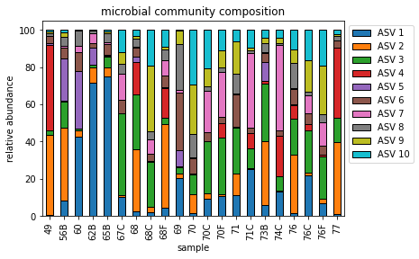

```python
rel_ab_ex.transpose().plot(kind='bar',
                           stacked = True,
                           edgecolor='black',
                           legend = False)

plt.title('microbial community composition')

plt.legend([f'ASV {i}' for i in range(1,len(rel_ab_ex.columns))],
          bbox_to_anchor = (1,1))

plt.xlabel('sample')
plt.ylabel('relative abundance')

plt.show()
```

### Alpha Diversity

```python
from skbio import diversity #ecology
```

```python
pacbio_chao1_div = pd.DataFrame(list(diversity.alpha_diversity(counts = pacbio_rel_ab.transpose(),metric = 'chao1')),
             columns = ['chao1'],index = pacbio_rel_ab.transpose().index)
```

```python
pacbio_shannon_div = pd.DataFrame(list(diversity.alpha_diversity(counts = pacbio_rel_ab.transpose(),metric = 'shannon')),
             columns = ['shannon'],index = pacbio_rel_ab.columns)
```

```python
pacbio_div_metr = pd.concat([pacbio_chao1_div,pacbio_shannon_div], axis  =1)
```

```python
pacbio_div_metr
```

|  | chao1 | shannon |
| --- | --- | --- |
| 49 | 289.0 | 5.212772 |
| 56B | 412.0 | 6.430819 |
| 60 | 252.0 | 4.699384 |
| 62B | 462.0 | 5.749731 |
| 65B | 523.0 | 5.808869 |
| 67C | 742.0 | 7.719165 |
| 68 | 355.0 | 6.388085 |
| 68C | 994.0 | 8.275257 |
| 68F | 693.0 | 7.959856 |
| 69 | 364.0 | 6.012064 |
| 70 | 721.0 | 7.983420 |
| 70C | 426.0 | 7.617373 |
| 70F | 826.0 | 7.732552 |
| 71 | 334.0 | 6.828541 |
| 71C | 866.0 | 7.873540 |
| 73B | 320.0 | 6.181681 |
| 74C | 928.0 | 7.429261 |
| 76 | 794.0 | 7.921173 |
| 76C | 702.0 | 8.135755 |
| 76F | 861.0 | 8.252502 |
| 77 | 385.0 | 5.793171 |

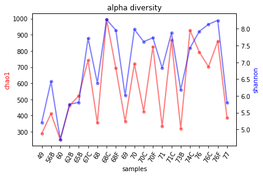

```python
fig,ax = plt.subplots()


ax1 = ax.twinx()

sns.lineplot(data = pacbio_div_metr, x = pacbio_div_metr.index, y = 'chao1',
             marker = 'o', linewidth = 2, ax = ax, color = 'red', alpha = 0.5)
sns.lineplot(data = pacbio_div_metr, x = pacbio_div_metr.index, y = 'shannon',
             marker = 'o', linewidth = 2, ax = ax1, color = 'blue', alpha = 0.5)

ax1.set_ylabel('shannon', color = 'blue')

ax.set_ylabel('chao1', color = 'red')

ax.set_xlabel('samples')
ax.set_xticks(range(len(pacbio_div_metr.index)),pacbio_div_metr.index.tolist(),rotation=60)

plt.title('alpha diversity')

plt.show()
```

```python
#add metadata informations
```

```python
metadata = pd.read_csv('16s_metadata.csv')
```

```python
metadata
```

|  | sample | group |
| --- | --- | --- |
| 0 | 49 | A |
| 1 | 56B | A |
| 2 | 60 | A |
| 3 | 62B | A |
| 4 | 65B | A |
| 5 | 67C | A |
| 6 | 68 | A |
| 7 | 68C | B |
| 8 | 68F | B |
| 9 | 69 | B |
| 10 | 70 | B |
| 11 | 70C | B |
| 12 | 70F | B |
| 13 | 71 | B |
| 14 | 71C | C |
| 15 | 73B | C |
| 16 | 74C | C |
| 17 | 76 | C |
| 18 | 76C | C |
| 19 | 76F | C |
| 20 | 77 | C |

```python
new_d = pacbio_div_metr.reset_index(names='sample').merge(metadata)
```

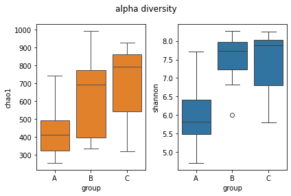

```python
fig,ax = plt.subplots(1,2)
sns.boxplot(data = new_d, x = 'group', y = 'chao1', ax = ax[0], color = 'tab:orange')
sns.boxplot(data = new_d, x = 'group', y = 'shannon', ax = ax[1], color = 'tab:blue')

fig.suptitle('alpha diversity')

plt.tight_layout()

plt.show()
```

# Beta Diversity

```python
from scipy.cluster.hierarchy import linkage, dendrogram
from scipy.spatial.distance import pdist
```

```python
pacbio_dist_matr = pdist(pacbio_feat_tab.transpose(), metric = 'braycurtis')
```

```python
pacbio_link = linkage(pacbio_dist_matr, method = 'single', metric = 'braycurtis')
```

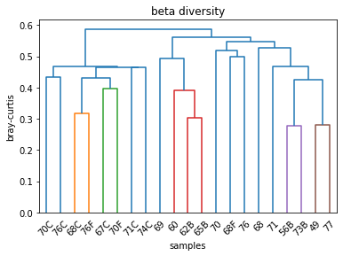

```python
dendrogram(pacbio_link, orientation = 'top',
           labels = pacbio_feat_tab.transpose().index.tolist(),
          leaf_font_size=10)

plt.title('beta diversity')
plt.ylabel('bray-curtis')
plt.xlabel('samples')

plt.show()
```

```python
conv_g = dict(zip(metadata['sample'],metadata['group']))
```

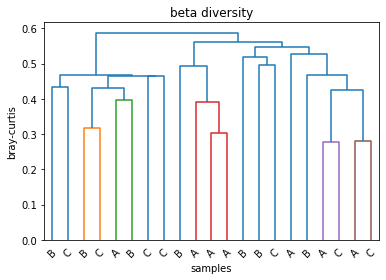

```python
dendrogram(pacbio_link, orientation = 'top',
           labels = [conv_g[e] for e in pacbio_feat_tab.transpose().index.tolist()],
          leaf_font_size=10)

plt.title('beta diversity')
plt.ylabel('bray-curtis')
plt.xlabel('samples')

plt.show()
```

### Finding Motif in a sequence

## Importing FASTA

### Basic Statistic

```python
from Bio import SeqIO
```

```python
file = pd.DataFrame({'sequence':{rec.id:str(rec.seq) for rec in SeqIO.parse('dna-sequences.fasta','fasta')}})
```

```python
file['sequence'].apply(len).describe()
```

```
count    4545.000000
mean     1436.403520
std        31.887304
min      1040.000000
25%      1407.000000
50%      1444.000000
75%      1458.000000
max      1588.000000
Name: sequence, dtype: float64
```

```python
file
```

|  | sequence |
| --- | --- |
| 000e74b14c8f0c22656b347e146b0936 | GATGAACGCTGGCGGCGTGCTTAACACATGCAAGTCGAACGGGAAT... |
| 0017fe9d68d9cc01e25ba7bcfd6012a0 | AATGAACGTTGGCGGCGTGGATTAGGCATGCAAGTCGAGCGAGAAG... |
| 0031d1b9ef6e023e9f4b3ff30345f581 | AACGTACGCTGGCGGCACGCCTAACACATGCAAGTCGAACGGAGTA... |
| 0034ee2d7d3cc684d77937de0fce926d | AATGAACGTTAGCGGCGTGGATTAGGCATGCAAGTCGAGCGAGAAG... |
| 00472373791cfe3f6444b405264fb560 | AATGAACGCTGGCGGCGTGGATAAGACATGCAAGTCGAACGAGGAA... |
| ... | ... |
| ff8fefa5b3b8a76363210909884c05fd | AACGAACGCTGGCGGCAGGCCTAACACATGCAAGTCGAGCGAGACC... |
| ff9b9d9ca8cb02ff816778003d017d49 | ATTGAACGCTGGCGGCATGCTTAACACATGCAAGTCGAACGGCAGC... |
| ffb25f3933ef1348e0dcf82e979883a7 | AACGAACGCTGGCGGCACGCCTAACACATGCAAGTCGAGCGCTCAC... |
| ffcfce4f0477e690b5f33866db20e1e7 | GATGAACGCTGGCGGCGTGCTTAACACATGCAAGTCGAACGAAGTC... |
| ffd25318bec5daecbff8312f29531b8b | AATGAACGTTGGCGGCGTGGATTAGGCATGCAAGTCGAGCGAGAAT... |

4545 rows × 1 columns

```python
TATATA = file[file['sequence'].str.contains('TGAA')]
```

### Writing FASTA

```python
with open('TATATA.fasta','w') as file:
    for header, seq in TATATA.to_dict()['sequence'].items():
        file.writelines('>'+header+'\n')
        file.writelines(seq+'\n')
```

## Statistics

```python
metadata = pd.read_csv('16s_metadata.csv')
```

```python
stat = pacbio_div_metr.reset_index(names='sample').merge(metadata, on='sample')
```

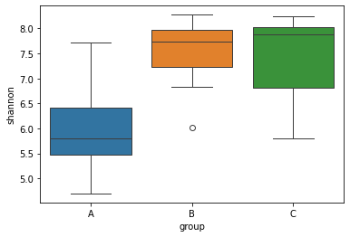

```python
sns.boxplot(data = stat, x = 'group', y = 'shannon', hue = 'group')
plt.show()
```

We want to perform an *ANOVA* test to evaluate if the difference on alpha diversity between groups is significant. In order to do so, we need to respect the assumption of the test:

- sample size >5
- normality
- homoschedasticity

```python
import pingouin as pg  #statistics
```

```python
stat.groupby('group')['sample'].count()
```

```
group
A    7
B    7
C    7
Name: sample, dtype: int64
```

```python
pg.normality(data = stat, dv = 'shannon', group = 'group', method = 'shapiro', alpha= 0.05)
```

| group | W | pval | normal |
| --- | --- | --- | --- |
| A | 0.960935 | 0.826716 | True |
| B | 0.865786 | 0.170447 | True |
| C | 0.826421 | 0.073988 | True |

```python
pg.homoscedasticity(data = stat, dv = 'shannon', group = 'group', method = 'levene', alpha = 0.05)
```

|  | W | pval | equal_var |
| --- | --- | --- | --- |
| levene | 0.122956 | 0.885039 | True |

```python
pg.anova(data = stat, dv='shannon',between='group')
```

|  | Source | ddof1 | ddof2 | F | p-unc | np2 |
| --- | --- | --- | --- | --- | --- | --- |
| 0 | group | 2 | 18 | 5.61696 | 0.012719 | 0.384277 |

```python
pg.pairwise_tukey(data=stat, dv = 'shannon', between = 'group')
```

|  | A | B | mean(A) | mean(B) | diff | se | T | p-tukey | hedges |
| --- | --- | --- | --- | --- | --- | --- | --- | --- | --- |
| 0 | A | B | 6.001261 | 7.487009 | -1.485748 | 0.492877 | -3.014441 | 0.019401 | -1.564908 |
| 1 | A | C | 6.001261 | 7.369583 | -1.368323 | 0.492877 | -2.776196 | 0.031820 | -1.307014 |
| 2 | B | C | 7.487009 | 7.369583 | 0.117426 | 0.492877 | 0.238246 | 0.969247 | 0.122892 |

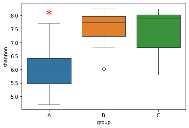

```python
sns.boxplot(data = stat, x = 'group', y = 'shannon', hue = 'group')
plt.text(x = -0.06, y = 7.9, s = '*', size = 25, color = 'red')
plt.show()
```

# Seaborn vs Matplotlib

```python
data = sns.load_dataset('penguins')
```

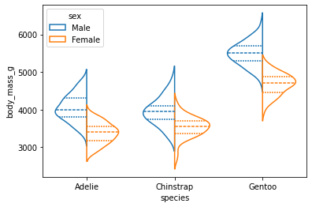

```python
sns.violinplot(data = data, x = 'species',
               y='body_mass_g', hue='sex',
              split=True, fill = False,
              inner='quart')
plt.show()
```

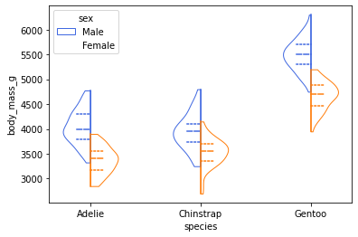

```python
c={'Male':'royalblue','Female':'tab:orange'}
sd={'Male':'low','Female':'high'}

i = 0
for s in ['Adelie','Chinstrap','Gentoo']:
    for x in ['Male','Female']:

        part33 = plt.violinplot(dataset=data.query('species==@s&sex==@x')['body_mass_g'].dropna(),
                                quantiles=[0.25,0.5,0.75],
                                positions=[i],side=sd[x],points=10000)
        for pc in part33['bodies']:
            pc.set_color('white')
            pc.set_edgecolor(c[x])
            pc.set_alpha(1)

        part33['cmins'].set_linewidth(0)
        part33['cmaxes'].set_linewidth(0)
        part33['cbars'].set_color(c[x])

        part33['cquantiles'].set_color(c[x])
        part33['cquantiles'].set_linestyle(['dotted','dashed','dotted'])


        i+=0
    i+=1

# for partname in ('cbars','cmins','cmaxes','cmeans','cmedians'):

plt.ylabel('body_mass_g')
plt.xlabel('species')
plt.xticks([0,1,2],['Adelie','Chinstrap','Gentoo'])

plt.legend(['Male','Female'],loc='upper left', title ='sex')

plt.show()
```